# ESTADISTICA PARA EL ANALISIS POLITICO II

- Profesor: [Dr. José Manuel Magallanes, Ph.D.](http://www.pucp.edu.pe/profesor/jose-manuel-magallanes/)
  - Profesor del Departamento de Ciencias Sociales, Sección de Ciencia Política y Gobierno.
  - [Oficina 105](https://goo.gl/maps/xuGeG6o9di1i1y5m6) - Edificio CISEPA / ECONOMIA / CCSS
  - Telefono: (51) 1 - 6262000 anexo 4302
  - Correo Electrónico: jmagallanes@pucp.edu.pe

## Análisis de Conglomerados: Estrategia de Partición

Como su nombre lo indica, la estrategia de partición busca partir los casos en grupos. El algoritmo básico estable puntos que deben atraer a los casos, tal que estos se separen. Claro está, que estos puntos atractores van moviendose conforme los grupos se van formando, hasta que al final se ha partido todos los casos.

Hay diversos algoritmos que buscan una implementación de estos principios básicos. El más conocido es el de **K-medias**, pero para ciencias sociales tiene la desventaja que requiere que todas las variables sean numéricas, no siendo muy eficiente ante categorías. Es decir, como mencionamos en la intro, la técnica de *k-means* no usa distancias entre categóricas, sólo entre numéricas ([la distancia *Euclideana*](https://en.wikipedia.org/wiki/Euclidean_distance)).

La alternativa a las necesidades en ciencias sociales es la técnica de **k-medoides**. Esta técnica trabaja muy bien con las distancias euclideas, pero también con otras distancias como la [**Mahattan**](https://en.wikipedia.org/wiki/Taxicab_geometry) (revisar este [debate](https://datascience.stackexchange.com/questions/20075/when-would-one-use-manhattan-distance-as-opposite-to-euclidean-distance)). En particular, usaremos la [distancia Gower](https://www.linkedin.com/pulse/simplifying-gower-coefficient-vineet-tanna) útil para todos tipo de escalas.

El algoritmo de los k-medioides es explicado con detalles en este video:

[video not shown]

Traigamos nuevamente los datos del Democracy Index:

```r
# coleccion
library(htmltab)
demolink = "https://en.wikipedia.org/wiki/Democracy_Index"
demopath = '//*[@id="mw-content-text"]/div/table[2]/tbody'
demo<- htmltab(doc = demolink, which =demopath)

# limpieza
library(stringr)
library(magrittr)
names(demo)=str_split(names(demo),">>",simplify = T)[,1]%>%gsub('\\s','',.)
demo[,-c(1,8,9)]=lapply(demo[,-c(1,8,9)], trimws,whitespace = "[\\h\\v]") # no blanks

# preparación
demo=demo[,-c(1)] #sin Rank
demo[,-c(1,8,9)]=lapply(demo[,-c(1,8,9)], as.numeric) # a numerico


# veamos que tenemos:
str(demo)
```

```
## 'data.frame':    167 obs. of  9 variables:
##  $ Country                        : chr  "Norway" "Iceland" "Sweden" "New Zealand" ...
##  $ Score                          : num  9.87 9.58 9.39 9.26 9.22 9.15 9.15 9.14 9.09 9.03 ...
##  $ Electoralprocessandpluralism: num  10 10 9.58 10 10 9.58 9.58 10 10 9.58 ...
##  $ Functioningofgovernment      : num  9.64 9.29 9.64 9.29 9.29 7.86 9.64 8.93 8.93 9.29 ...
##  $ Politicalparticipation       : num  10 8.89 8.33 8.89 8.33 8.33 7.78 8.33 7.78 7.78 ...
##  $ Politicalculture              : num  10 10 10 8.13 9.38 10 8.75 8.75 8.75 9.38 ...
##  $ Civilliberties                : num  9.71 9.71 9.41 10 9.12 10 10 9.71 10 9.12 ...
##  $ Regimetype                     : chr  "Full democracy" "Full democracy" "Full democracy" "Full democracy" ...
##  $ Continent                     : chr  "Europe" "Europe" "Europe" "Oceania" ...
```

Recuerda que cuando se usa **as.numeric()** pueden generarse valores perdidos si el texto original no es un número o tiene espacios vacíos. Es mejor quedarse con los valores completos, pero algunas técnicas trabajan bien aun en la presencia de *NA*s.

Ya sabemos a qué grupo pertenece cada país segun *The Economist*. Ahora nos toca aplicar la técnica de clusterización para ver qué diferencias obtenemos.

Como pasos previo, hagamos dos cosas:

- Los nombres de cada caso aparezcan en las gráficas:

```r
row.names(demo)=demo$Country
```

- Solo trabajemos con data sin valores perdidos:

```r
# alternativa a complete.cases:
demo=na.omit(demo)
```

Ahora podemos continuar:

### 1. Calcular distancias:

```r
library(cluster)

# usar en C() las dimensiones de interes:
g.dist = daisy(demo[,c(3:7)], metric="gower")
```

### 2. Proponer cantidad de clusters:

Como ya sabemos cuantos grupos habría, usamos esa cantidad para los clusters.

```r
pam.resultado=pam(g.dist,4,cluster.only = F)

demo$clusterPT=pam.resultado$cluster
```

### 3. Explorar Resultados

Aquí corresponde saber las caracteristicas de los paises en cada cluster. Veamos el resultado **preliminar** al aplicar **aggregate** con la función **each** (esta última está en la biblioteca *plyr*):

```r
library(plyr) # para funcion "each"..

# nota el uso de as.matrix con cbind:
aggregate(as.matrix(cbind(demo[,c(3:7)]))~ clusterPT, data=demo,
          FUN=plyr::each(MD = median, Media = mean))
```

```
##   clusterPT Electoralprocessandpluralism.MD
## 1         1                          9.5800000
## 2         2                          8.7500000
## 3         3                          4.8300000
## 4         4                          0.5000000
##   Electoralprocessandpluralism.Media Functioningofgovernment.MD
## 1                             9.3282927                     7.860000
## 2                             8.2667391                     5.710000
## 3                             4.9518919                     3.570000
## 4                             0.9265116                     2.140000
##   Functioningofgovernment.Media Politicalparticipation.MD
## 1                        7.996585                    6.670000
## 2                        5.763913                    6.110000
## 3                        3.488378                    4.440000
## 4                        2.178372                    3.330000
##   Politicalparticipation.Media Politicalculture.MD
## 1                       7.127805             7.500000
## 2                       5.918696             5.000000
## 3                       4.774595             5.630000
## 4                       3.152326             5.000000
##   Politicalculture.Media Civilliberties.MD Civilliberties.Media
## 1                7.730732           9.120000              8.917561
## 2                5.111522           7.060000              7.033696
## 3                5.036757           4.710000              4.689730
## 4                4.552093           2.650000              2.339767
```

Podemos volver esa tabla resumen un data frame:

```r
# guardando resultado anterior en objeto "agg":
agg=aggregate(as.matrix(cbind(demo[,c(3:7)]))~ clusterPT,
              data=demo, # luego las funciones que deseas
              FUN=plyr::each(MD = median, Media = mean))

# convertir en data frame, y
tablaResumen=t(as.data.frame(agg))
tablaResumen
```

```
##                                           [,1]     [,2]     [,3]      [,4]
## clusterPT                             1.000000 2.000000 3.000000 4.0000000
## Electoralprocessandpluralism.MD    9.580000 8.750000 4.830000 0.5000000
## Electoralprocessandpluralism.Media 9.328293 8.266739 4.951892 0.9265116
## Functioningofgovernment.MD          7.860000 5.710000 3.570000 2.1400000
## Functioningofgovernment.Media       7.996585 5.763913 3.488378 2.1783721
## Politicalparticipation.MD           6.670000 6.110000 4.440000 3.3300000
## Politicalparticipation.Media        7.127805 5.918696 4.774595 3.1523256
## Politicalculture.MD                  7.500000 5.000000 5.630000 5.0000000
## Politicalculture.Media               7.730732 5.111522 5.036757 4.5520930
## Civilliberties.MD                    9.120000 7.060000 4.710000 2.6500000
## Civilliberties.Media                 8.917561 7.033696 4.689730 2.3397674
```

Para una mejor presentacion en la web, tienes la funcion **[kable()](https://cran.r-project.org/web/packages/kableExtra/vignettes/awesome_table_in_html.html)**:

```r
library(knitr)
library(kableExtra)
kable(tablaResumen, format = "html", digits = 2)%>%
  kable_styling()
```

| clusterPT | 1.00 | 2.00 | 3.00 | 4.00 |
| --- | --- | --- | --- | --- |
| Electoralprocessandpluralism.MD | 9.58 | 8.75 | 4.83 | 0.50 |
| Electoralprocessandpluralism.Media | 9.33 | 8.27 | 4.95 | 0.93 |
| Functioningofgovernment.MD | 7.86 | 5.71 | 3.57 | 2.14 |
| Functioningofgovernment.Media | 8.00 | 5.76 | 3.49 | 2.18 |
| Politicalparticipation.MD | 6.67 | 6.11 | 4.44 | 3.33 |
| Politicalparticipation.Media | 7.13 | 5.92 | 4.77 | 3.15 |
| Politicalculture.MD | 7.50 | 5.00 | 5.63 | 5.00 |
| Politicalculture.Media | 7.73 | 5.11 | 5.04 | 4.55 |
| Civilliberties.MD | 9.12 | 7.06 | 4.71 | 2.65 |
| Civilliberties.Media | 8.92 | 7.03 | 4.69 | 2.34 |

### 4. Comparar

Usemos una tabla de contingencia para verificar la asignación:

```r
table(demo$clusterPT,demo$Regimetype,dnn = c('clusterPT','TipoEconomist'))
```

```
##          TipoEconomist
## clusterPT Authoritarian Flawed democracy Full democracy Hybrid regime
##         1             0               21             20             0
##         2             0               34              0            12
##         3            10                0              0            27
##         4            43                0              0             0
```

Nótese que: * El cluster 1 ha juntado *todas* las democracias plenas y ha admitido a 21 de las débiles. Así, dejó entrar a estos paises:

```r
demo[demo$clusterPT==1 & demo$Regimetype=="Flawed democracy",'Country']
```

```
##  [1] "South Korea"    "Japan"          "Chile"          "Estonia"
##  [5] "United States"  "Cape Verde"     "Portugal"       "Botswana"
##  [9] "France"         "Israel"         "Belgium"        "Taiwan"
## [13] "Italy"          "Czech Republic" "Cyprus"         "Slovenia"
## [17] "Lithuania"      "Latvia"         "Jamaica"        "Malaysia"
## [21] "Hong Kong"
```

### 5. Visualizar:

Veamos lo obtenido:

```r
library(factoextra)
```

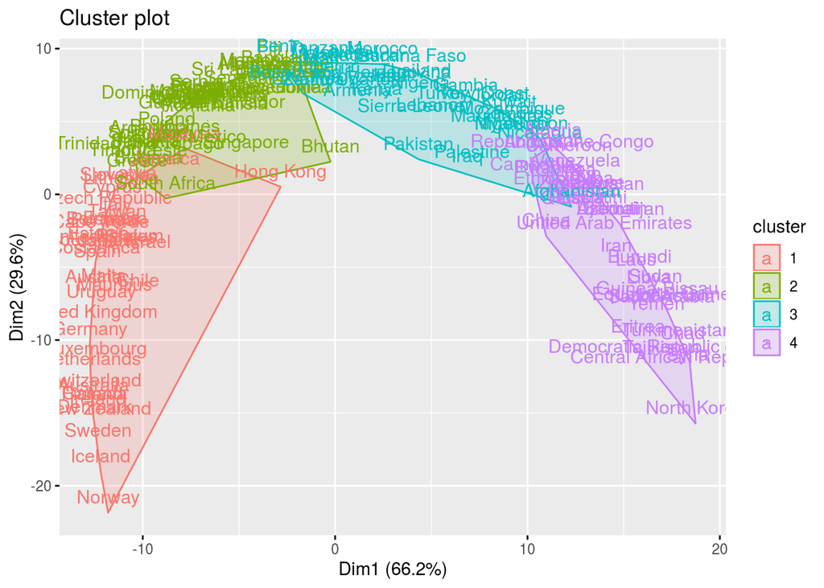

```r
fviz_cluster(object = list(data=g.dist, cluster = demo$clusterPT),
             geom = c("text"),
             ellipse.type = "convex")
```

Si deseamos una mejor gráfica:

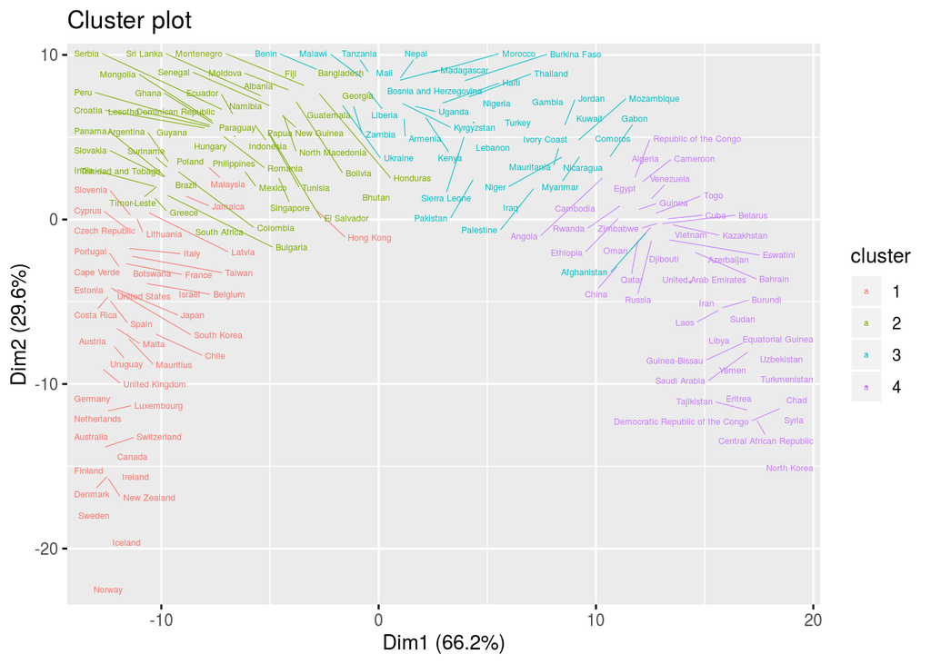

```r
library(ggrepel)

fviz_cluster(object = list(data=g.dist, cluster = demo$clusterPT),
             geom = c("text"),
             ellipse = FALSE,labelsize = 5,
             repel = T)
```

Nota que esta técnica asignará un cluster a cada elemento.

al INICIO

[VOLVER A CONTENIDOS](https://politicaygobiernopucp.github.io/estadistica_anapol2/)